# Diabetes130

Chris Tinley

2024-11-07

# Introduction

The dataset analyed for this project concerns hospital admissions for patients with diabetes at 130 different hospitals called, “Diabetes 130-US Hospitals for Years 1999-2008.” from the UC Irvine Machine Learning Repository. This is a rich dataset with 50 columns about the patient and their hospital stay.

I narrowed my focus to look at determinants of readmission and length of stay as these are important variables in terms of hospital economics. There are 717 unique diagnosis codes, so I narrowed the focus again down to four diagnoses (acute heart attack, hearth failure, pneumonia, coronary artery bypass graft) that are particularly salient because Centers for Medicare and Medicare (CMS) levies penalties on hospitals that have readmissions within 30 days for these diagnoses. I was also interested to see if discharge disposition was associated with readmission (ie., was the patient discharged home, home with services, to rehab). I looked at the breakdown for the sample itself and ran linear and multinomial analyses to figure out the most important factors contributing to length of stay and readmission status for these diagnoses.

## Part I – Exploring

```r
## Load data from csv ##
v0_hospital_data <- read.csv("diabetic_data.csv")

### Part 1: Exploring ###
## Cleaning the data ##
# Race Column: Replace "?" with "unknown"
cleaned_hospital_data <- v0_hospital_data %>%
  mutate(column = recode(race, "?" = "unknown"))
# Age Column: Convert ranges to ordered factor for analysis
age_ranges = c("[0-10)","[10-20)","[20-30)","[30-40)","[40-50)","[50-60)", "[60-70)", "[70-80)", "[80-90)", "[90-100)")
age_ordered_factor <- factor(cleaned_hospital_data$age,
  levels = c("[0-10)","[10-20)","[20-30)","[30-40)","[40-50)","[50-60)", "[60-70)", "[70-80)", "[80-90)", "[90-100)"),
    ordered = TRUE)
# Gender Column: Replace "Unknown/Invalid" with "unknown"
cleaned_hospital_data <- cleaned_hospital_data %>%
  mutate(column = recode(gender, "Unknown/Invalid" = "unknown"))
# Weight Column: Replace "?" with "unknown"
cleaned_hospital_data <- cleaned_hospital_data %>%
  mutate(column = recode(weight, "?" = "unknown"))
# "admission_type_id" Column: Load reference table
admission_type_id_reference <- read.csv("admission_type_id.csv")
# "discharge_disposition_id" Column
  #Load reference table
    discharge_disposition_id_reference <- read.csv("discharge_disposition_id.csv")
  # Create and mapdischarge disposition groups
    dc_home <- c(1, 7, 16, 17, 19)
    dc_home_with_services <- c(6, 8, 13)
    dc_rehab <- c(3, 4, 15, 22, 24)
    dc_inpatient <- c(2, 5, 9,  10, 12, 20, 23, 27, 28, 29, 30)
    dc_other <- c(11,   14, 18, 21, 25, 26)
  # Create and map CMS readmission penalty diagnosis groups
    acute_MCI <- 410
    COPD <- c(491, 492, 496, 490)
    CHF <- c(428)
    Pneumonia <- c(480, 481, 482, 483, 484, 485, 486)
    CABG <- c(414)
    #OMIT THA_TKA due to lack of data <- c("V43")
# Create a new column for the discharge group
  cleaned_hospital_data <- cleaned_hospital_data %>%
    mutate(discharge_group = case_when(
      discharge_disposition_id %in% dc_home ~ "Home",
      discharge_disposition_id %in% dc_home_with_services ~ "Home with Services",
      discharge_disposition_id %in% dc_rehab ~ "Rehabilitation",
      discharge_disposition_id %in% dc_inpatient ~ "Inpatient Care",
      discharge_disposition_id %in% dc_other ~ "Other",
      TRUE ~ "Other"  # Catch any unexpected values
    ))
  # Create a new column for the diagnosis group
  cleaned_hospital_data <- cleaned_hospital_data %>%
    mutate(diagnosis_group = case_when(
      diag_1 %in% acute_MCI ~ "Acute Myocardial Infarction",
      diag_1 %in% CHF ~ "Congestive Heart Failure",
      diag_1 %in% Pneumonia ~ "Pneumonia",
      diag_1 %in% CABG ~ "Coronary Artery Bypass Graft",
      TRUE ~ "Other"  # Catch any unexpected values
    ))



## Descriptive statistics and graphs for interesting variables ##
# Age statistics
summary(age_ordered_factor)
```

```
##   [0-10)  [10-20)  [20-30)  [30-40)  [40-50)  [50-60)  [60-70)  [70-80)
##      161      691     1657     3775     9685    17256    22483    26068
##  [80-90) [90-100)
##    17197     2793
```

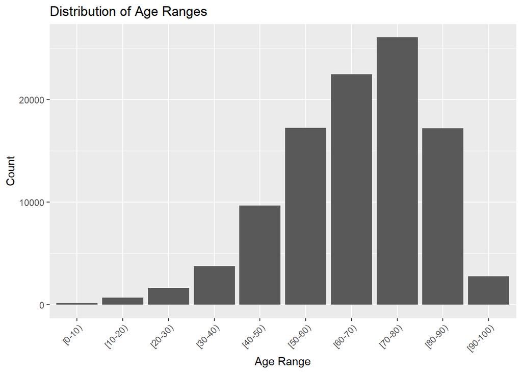

```r
age_ranges <- levels(age_ordered_factor)
age_counts <- summary(age_ordered_factor)
age_summary_df <- data.frame(
  age_ranges = age_ranges,
  count = as.numeric(age_counts))

ggplot(age_summary_df, aes(x = age_ranges, y = count)) +
  geom_bar(stat = "identity") +
  labs(title = "Distribution of Age Ranges", x = "Age Range", y = "Count") +
  theme(axis.text.x = element_text(angle = 45, hjust = 1))
```

```r
# Number of lab procedures statistics
describe(cleaned_hospital_data$num_lab_procedures)
```

```
##    vars      n mean    sd median trimmed   mad min max range  skew kurtosis
## X1    1 101766 43.1 19.67     44   43.79 19.27   1 132   131 -0.24    -0.25
##      se
## X1 0.06
```

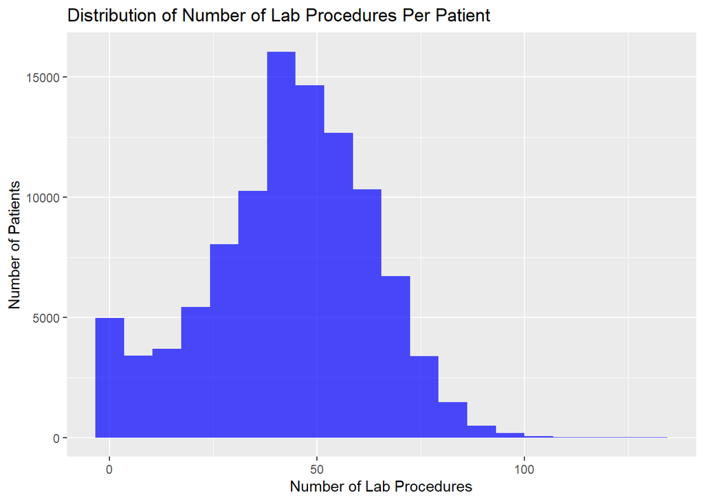

```r
ggplot(cleaned_hospital_data, aes(x = num_lab_procedures)) +
  geom_histogram(bins = 20, fill = "blue", alpha = 0.7) +
  labs(title = "Distribution of Number of Lab Procedures Per Patient", x = "Number of Lab Procedures", y = "Number of Patients")
```

```r
# Number of medications statistics
describe(cleaned_hospital_data$num_medications)
```

```
##    vars      n  mean   sd median trimmed  mad min max range skew kurtosis   se
## X1    1 101766 16.02 8.13     15   15.23 7.41   1  81    80 1.33     3.47 0.03
```

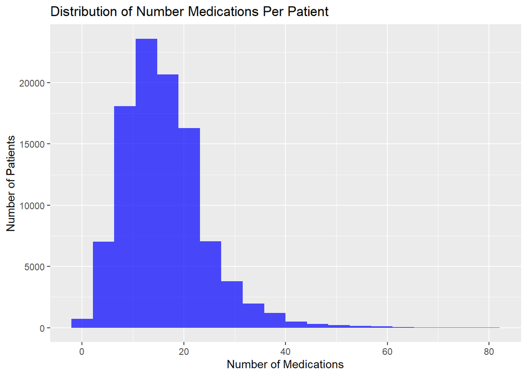

```r
ggplot(cleaned_hospital_data, aes(x = num_medications)) +
  geom_histogram(bins = 20, fill = "blue", alpha = 0.7) +
  labs(title = "Distribution of Number Medications Per Patient", x = "Number of Medications", y = "Number of Patients")
```

```r
# Length of stay statistics
describe(cleaned_hospital_data$time_in_hospital)
```

```
##    vars      n mean   sd median trimmed  mad min max range skew kurtosis   se
## X1    1 101766  4.4 2.99      4    3.99 2.97   1  14    13 1.13     0.85 0.01
```

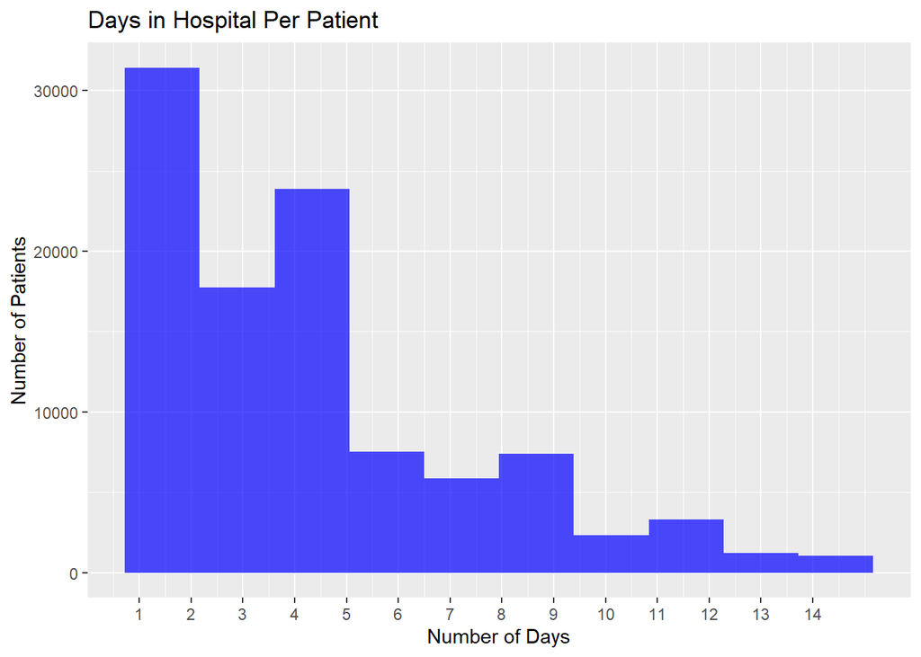

```r
ggplot(cleaned_hospital_data, aes(x = time_in_hospital)) +
  geom_histogram(bins = 10, fill = "blue", alpha = 0.7) +
  scale_x_continuous(breaks=seq(min(cleaned_hospital_data$time_in_hospital), max(cleaned_hospital_data$time_in_hospital), by=1)) +
  labs(title = "Days in Hospital Per Patient", x = "Number of Days", y = "Number of Patients")
```

```r
# Readmitted statistics
readmitted_summary <- cleaned_hospital_data %>%
  group_by(readmitted) %>%
  dplyr::summarise(count = n()) %>%
  mutate(percentage = (count / sum(count)) * 100)
readmitted_summary
```

```
## # A tibble: 3 × 3
##   readmitted count percentage
##   <chr>      <int>      <dbl>
## 1 <30        11357       11.2
## 2 >30        35545       34.9
## 3 NO         54864       53.9
```

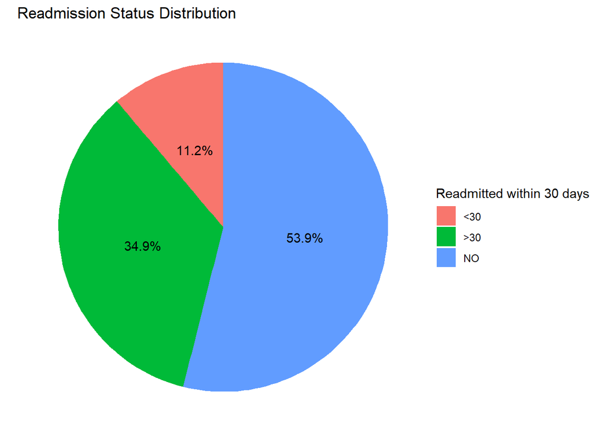

```r
ggplot(readmitted_summary, aes(x = "", y = percentage, fill = readmitted)) +
  geom_bar(stat = "identity", width = 1) +
  coord_polar("y", start = 0) +
  labs(title = "Readmission Status Distribution",
       fill = "Readmitted within 30 days",
       y = "Percentage") +
  theme_void() +
  geom_text(aes(label = paste0(round(percentage, 1), "%")),
            position = position_stack(vjust = 0.5))  # Add percentage labels
```

```r
# Raw Data Associations - Age
age_readmitted_summary <- cleaned_hospital_data %>%
  group_by(age, readmitted) %>%
  dplyr::summarise(count = n(), .groups = 'drop') %>%
  mutate(percentage = count / sum(count[readmitted == unique(readmitted)]) * 100)  # Calculate percentage for each age group

age_readmitted_summary_total <- cleaned_hospital_data %>%
  group_by(age, readmitted) %>%
  dplyr::summarise(count = n())
```

[output not shown]

```r
age_readmitted_summary
```

```
## # A tibble: 30 × 4
##    age     readmitted count percentage
##    <chr>   <chr>      <int>      <dbl>
##  1 [0-10)  <30            3    0.00295
##  2 [0-10)  >30           26    0.0255
##  3 [0-10)  NO           132    0.130
##  4 [10-20) <30           40    0.0393
##  5 [10-20) >30          224    0.220
##  6 [10-20) NO           427    0.420
##  7 [20-30) <30          236    0.232
##  8 [20-30) >30          510    0.501
##  9 [20-30) NO           911    0.895
## 10 [30-40) <30          424    0.417
## # ℹ 20 more rows
```

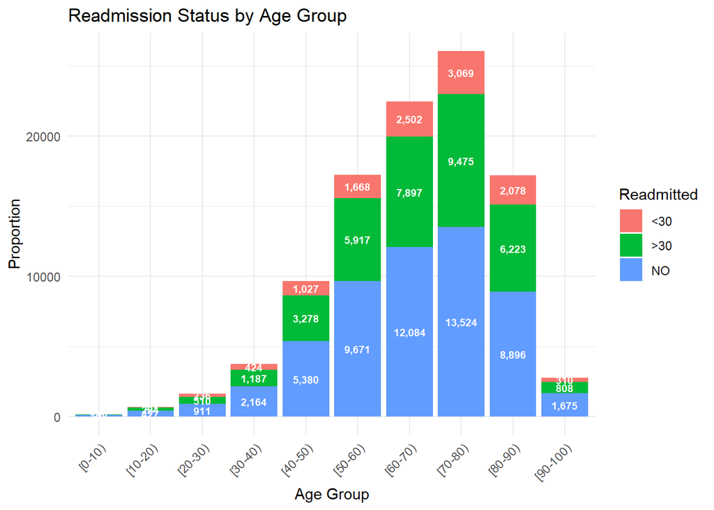

```r
ggplot(age_readmitted_summary_total, aes(x = age, y = count, fill = readmitted)) +
  geom_bar(stat = "identity", position = "stack") +
  geom_text(aes(label = scales::comma(count)),
            position = position_stack(vjust = 0.5), size = 2.5, color = "white", fontface = "bold") +  # Add percentage labels on bars
  labs(title = "Readmission Status by Age Group",
       x = "Age Group",
       y = "Proportion",
       fill = "Readmitted") +
  theme_minimal() +
  theme(axis.text.x = element_text(angle = 45, hjust = 1))
```

```r
# Raw Data Associations - Length of Stay
LOS_readmitted_summary <- cleaned_hospital_data %>%
  group_by(time_in_hospital, readmitted) %>%
  dplyr::summarise(count = n(), .groups = 'drop')
LOS_readmitted_summary_wide <- LOS_readmitted_summary %>%
  pivot_wider(names_from = readmitted, values_from = count)
LOS_readmitted_summary_wide
```

```
## # A tibble: 14 × 4
##    time_in_hospital `<30` `>30`    NO
##               <int> <int> <int> <int>
##  1                1  1162  4471  8575
##  2                2  1712  5919  9593
##  3                3  1894  6085  9777
##  4                4  1644  5064  7216
##  5                5  1199  3586  5181
##  6                6   949  2755  3835
##  7                7   752  2123  2984
##  8                8   625  1589  2177
##  9                9   412  1099  1491
## 10               10   336   838  1168
## 11               11   195   699   961
## 12               12   193   518   737
## 13               13   149   421   640
## 14               14   135   378   529
```

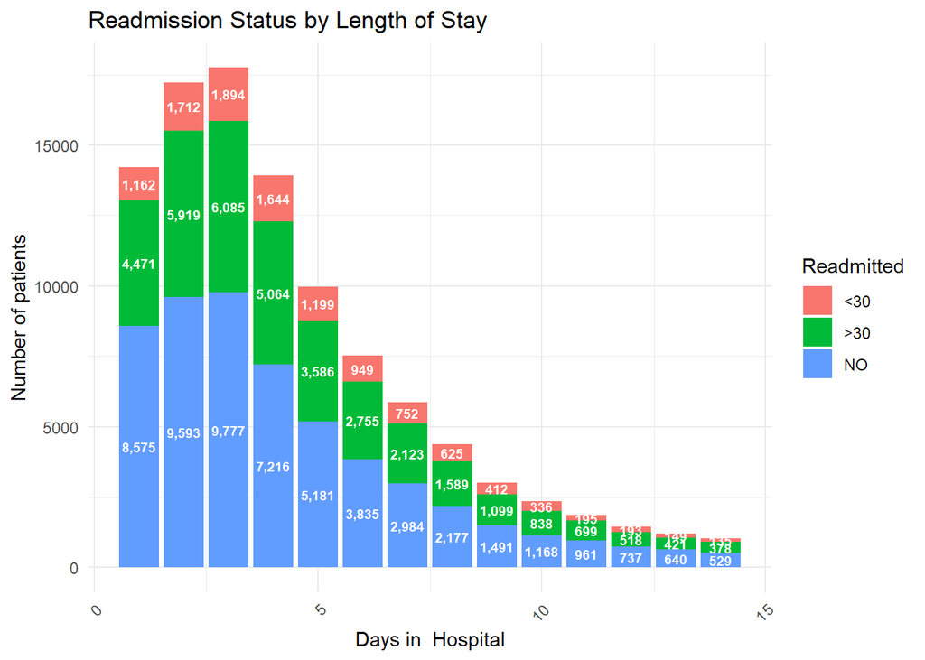

```r
ggplot(LOS_readmitted_summary, aes(x = time_in_hospital, y = count, fill = readmitted)) +
  geom_bar(stat = "identity", position = "stack") +  geom_text(aes(label = scales::comma(count)),
            position = position_stack(vjust = 0.5), size = 2.5, color = "white", fontface = "bold") +  # Add percentage labels on bars
  labs(title = "Readmission Status by Length of Stay",
       x = "Days in  Hospital",
       y = "Number of patients",
       fill = "Readmitted") +
  theme_minimal() +
  theme(axis.text.x = element_text(angle = 45, hjust = 1))
```

```r
  # by diagnosis
  avg_stay_by_diagnosis <- cleaned_hospital_data %>%
    group_by(diagnosis_group) %>%
    dplyr::summarise(avg_length_of_stay = mean(time_in_hospital, na.rm = TRUE),
                     count = n(),
                     .groups = 'drop') %>%
    arrange(desc(avg_length_of_stay))
  avg_stay_by_diagnosis
```

```
## # A tibble: 5 × 3
##   diagnosis_group              avg_length_of_stay count
##   <chr>                                     <dbl> <int>
## 1 Pneumonia                                  5.15  3982
## 2 Acute Myocardial Infarction                4.87  3614
## 3 Congestive Heart Failure                   4.57  6862
## 4 Other                                      4.40 80727
## 5 Coronary Artery Bypass Graft               3.47  6581
```

```r
# Raw Data Associations - Number of procedures
summary_statistics_procedures <- cleaned_hospital_data %>%
  group_by(readmitted) %>%
  dplyr::summarise(
    min_procedures = min(num_procedures, na.rm = TRUE),
    max_procedures = max(num_procedures, na.rm = TRUE),
    mean_procedures = mean(num_procedures, na.rm = TRUE),
    median_procedures = median(num_procedures, na.rm = TRUE),
    sd_procedures = sd(num_procedures, na.rm = TRUE),
    count = n())
summary_statistics_procedures
```

```
## # A tibble: 3 × 7
##   readmitted min_procedures max_procedures mean_procedures median_procedures
##   <chr>               <int>          <int>           <dbl>             <dbl>
## 1 <30                     0              6            1.28                 1
## 2 >30                     0              6            1.25                 1
## 3 NO                      0              6            1.41                 1
## # ℹ 2 more variables: sd_procedures <dbl>, count <int>
```

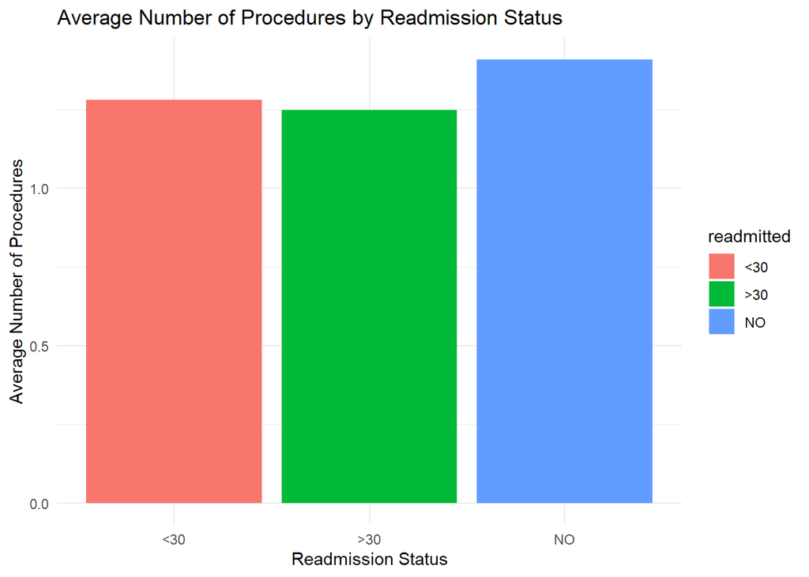

```r
ggplot(summary_statistics_procedures, aes(x = readmitted, y = mean_procedures, fill = readmitted)) +
  geom_bar(stat = "identity") +
  labs(title = "Average Number of Procedures by Readmission Status",
       x = "Readmission Status",
       y = "Average Number of Procedures") +
  theme_minimal()
```

```r
# Raw Data Associations - Number of medications
summary_statistics_meds <- cleaned_hospital_data %>%
  group_by(readmitted) %>%
  dplyr::summarise(
    min_meds = min(num_medications, na.rm = TRUE),
    max_meds = max(num_medications, na.rm = TRUE),
    mean_meds = mean(num_medications, na.rm = TRUE),
    median_meds = median(num_medications, na.rm = TRUE),
    sd_meds = sd(num_medications, na.rm = TRUE),
    count = n())
summary_statistics_meds
```

```
## # A tibble: 3 × 7
##   readmitted min_meds max_meds mean_meds median_meds sd_meds count
##   <chr>         <int>    <int>     <dbl>       <dbl>   <dbl> <int>
## 1 <30               1       81      16.9          16    8.10 11357
## 2 >30               1       70      16.3          15    7.62 35545
## 3 NO                1       79      15.7          14    8.43 54864
```

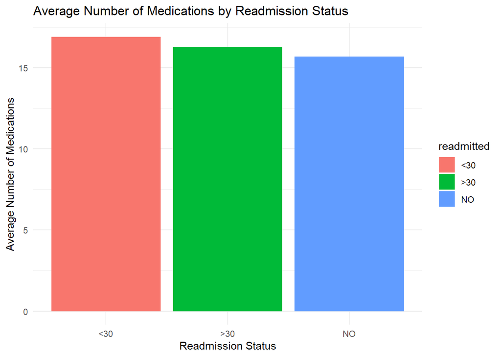

```r
ggplot(summary_statistics_meds, aes(x = readmitted, y = mean_meds, fill = readmitted)) +
  geom_bar(stat = "identity") +
  labs(title = "Average Number of Medications by Readmission Status",
       x = "Readmission Status",
       y = "Average Number of Medications") +
  theme_minimal()
```

## Part II: Expanding

```r
## Discharge disposition and readmission
# Created 5 sub-categories for d/c disposition in Part 1, time to sum them up
  # Summarize the number of observations in each group
  discharge_summary <- cleaned_hospital_data %>%
    group_by(discharge_group) %>%
    dplyr::summarise(count = n())
  discharge_summary
```

```
## # A tibble: 5 × 2
##   discharge_group    count
##   <chr>              <int>
## 1 Home               60890
## 2 Home with Services 13409
## 3 Inpatient Care      3900
## 4 Other               6694
## 5 Rehabilitation     16873
```

```r
  readmission_summary <- cleaned_hospital_data %>%
    group_by(discharge_group, readmitted) %>%
    dplyr::summarise(count = n(), .groups = 'drop')
    readmission_summary
```

```
## # A tibble: 15 × 3
##    discharge_group    readmitted count
##    <chr>              <chr>      <int>
##  1 Home               <30         5692
##  2 Home               >30        21749
##  3 Home               NO         33449
##  4 Home with Services <30         1672
##  5 Home with Services >30         5436
##  6 Home with Services NO          6301
##  7 Inpatient Care     <30          681
##  8 Inpatient Care     >30         1203
##  9 Inpatient Care     NO          2016
## 10 Other              <30          575
## 11 Other              >30         1410
## 12 Other              NO          4709
## 13 Rehabilitation     <30         2737
## 14 Rehabilitation     >30         5747
## 15 Rehabilitation     NO          8389
```

```r
  readmission_summary <- readmission_summary %>%
    group_by(discharge_group) %>%
    mutate(total_count = sum(count)) %>%
    mutate(percentage = (count / total_count) * 100) %>%
    ungroup()
  readmission_pivot <- readmission_summary %>%
    pivot_wider(names_from = readmitted, values_from = count, values_fill = 0)
  readmission_pivot
```

```
## # A tibble: 15 × 6
##    discharge_group    total_count percentage `<30` `>30`    NO
##    <chr>                    <int>      <dbl> <int> <int> <int>
##  1 Home                     60890       9.35  5692     0     0
##  2 Home                     60890      35.7      0 21749     0
##  3 Home                     60890      54.9      0     0 33449
##  4 Home with Services       13409      12.5   1672     0     0
##  5 Home with Services       13409      40.5      0  5436     0
##  6 Home with Services       13409      47.0      0     0  6301
##  7 Inpatient Care            3900      17.5    681     0     0
##  8 Inpatient Care            3900      30.8      0  1203     0
##  9 Inpatient Care            3900      51.7      0     0  2016
## 10 Other                     6694       8.59   575     0     0
## 11 Other                     6694      21.1      0  1410     0
## 12 Other                     6694      70.3      0     0  4709
## 13 Rehabilitation           16873      16.2   2737     0     0
## 14 Rehabilitation           16873      34.1      0  5747     0
## 15 Rehabilitation           16873      49.7      0     0  8389
```

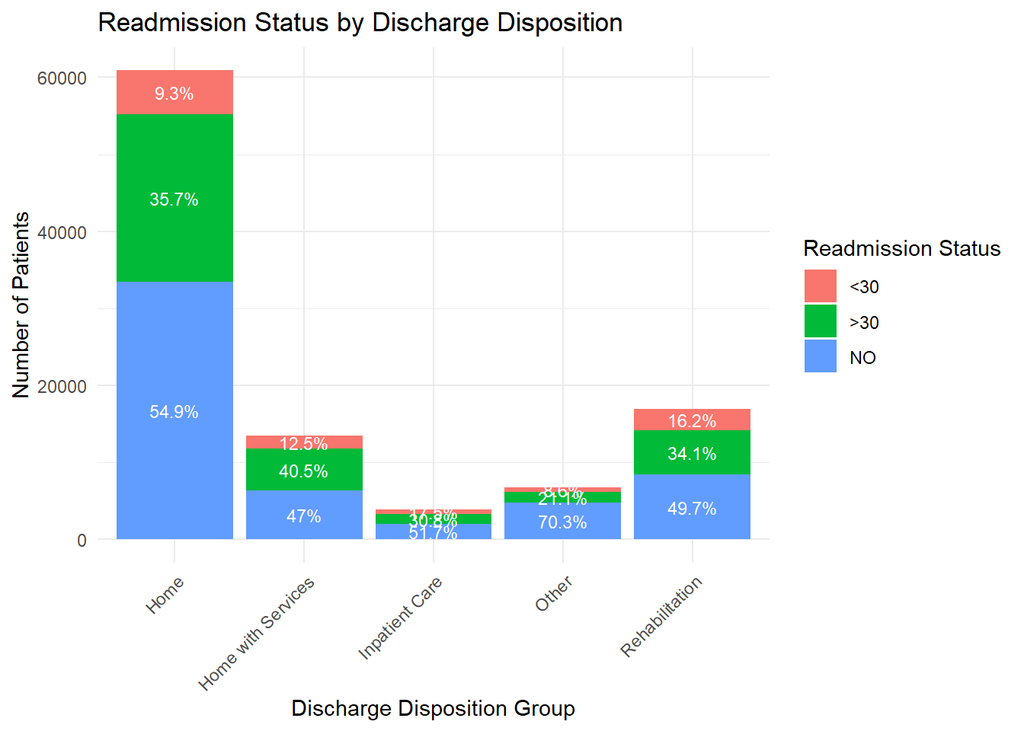

```r
  # Stacked bar chart
  ggplot(readmission_summary, aes(x = discharge_group, y = count, fill = readmitted)) +
    geom_bar(stat = "identity", position = "stack") +
    geom_text(aes(label = paste0(round(percentage, 1), "%")),
    position = position_stack(vjust = 0.5), size = 3, color = "white") +
    labs(title = "Readmission Status by Discharge Disposition",
         x = "Discharge Disposition Group",
         y = "Number of Patients",
         fill = "Readmission Status") +
    theme_minimal() +
    theme(axis.text.x = element_text(angle = 45, hjust = 1))
```

```r
## Diagnosis and readmission
    discharge_summary2 <- cleaned_hospital_data %>%
    group_by(diagnosis_group) %>%
    dplyr::summarise(total_count = n())
  discharge_summary2
```

```
## # A tibble: 5 × 2
##   diagnosis_group              total_count
##   <chr>                              <int>
## 1 Acute Myocardial Infarction         3614
## 2 Congestive Heart Failure            6862
## 3 Coronary Artery Bypass Graft        6581
## 4 Other                              80727
## 5 Pneumonia                           3982
```

```r
  readmission_summary2 <- cleaned_hospital_data %>%
    group_by(diagnosis_group, readmitted) %>%
    dplyr::summarise(count = n(), .groups = 'drop')
  readmission_summary2
```

```
## # A tibble: 15 × 3
##    diagnosis_group              readmitted count
##    <chr>                        <chr>      <int>
##  1 Acute Myocardial Infarction  <30          373
##  2 Acute Myocardial Infarction  >30         1065
##  3 Acute Myocardial Infarction  NO          2176
##  4 Congestive Heart Failure     <30          968
##  5 Congestive Heart Failure     >30         3089
##  6 Congestive Heart Failure     NO          2805
##  7 Coronary Artery Bypass Graft <30          595
##  8 Coronary Artery Bypass Graft >30         2125
##  9 Coronary Artery Bypass Graft NO          3861
## 10 Other                        <30         9056
## 11 Other                        >30        27713
## 12 Other                        NO         43958
## 13 Pneumonia                    <30          365
## 14 Pneumonia                    >30         1553
## 15 Pneumonia                    NO          2064
```

```r
  readmission_pivot2 <- readmission_summary2 %>%
    pivot_wider(names_from = readmitted, values_from = count, values_fill = 0)
  readmission_pivot2
```

```
## # A tibble: 5 × 4
##   diagnosis_group              `<30` `>30`    NO
##   <chr>                        <int> <int> <int>
## 1 Acute Myocardial Infarction    373  1065  2176
## 2 Congestive Heart Failure       968  3089  2805
## 3 Coronary Artery Bypass Graft   595  2125  3861
## 4 Other                         9056 27713 43958
## 5 Pneumonia                      365  1553  2064
```

```r
  # Merge total counts with readmission summary
  readmission_pivot2 <- readmission_pivot2 %>%
    left_join(discharge_summary2, by = "diagnosis_group")
  readmission_pivot2
```

```
## # A tibble: 5 × 5
##   diagnosis_group              `<30` `>30`    NO total_count
##   <chr>                        <int> <int> <int>       <int>
## 1 Acute Myocardial Infarction    373  1065  2176        3614
## 2 Congestive Heart Failure       968  3089  2805        6862
## 3 Coronary Artery Bypass Graft   595  2125  3861        6581
## 4 Other                         9056 27713 43958       80727
## 5 Pneumonia                      365  1553  2064        3982
```

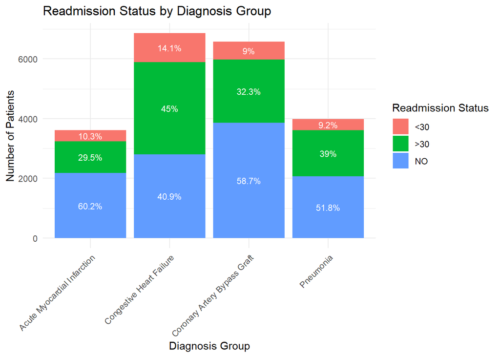

```r
  readmission_long <- readmission_pivot2 %>%
    pivot_longer(cols = c(NO, `>30`, `<30`), names_to = "readmitted", values_to = "count") %>%
    mutate(percentage = (count / total_count) * 100)

  # Stacked bar chart
  ggplot(readmission_long, aes(x = diagnosis_group, y = count, fill = readmitted)) +
    geom_bar(stat = "identity", position = "stack") +
    scale_x_discrete(limits = c("Acute Myocardial Infarction", "Congestive Heart Failure", "Coronary Artery Bypass Graft", "Pneumonia")) +
    geom_text(aes(label = paste0(round(percentage, 1), "%")),
              position = position_stack(vjust = 0.5), size = 3, color = "white") +
    labs(title = "Readmission Status by Diagnosis Group",
         x = "Diagnosis Group",
         y = "Number of Patients",
         fill = "Readmission Status") +
    theme_minimal() +
    theme(axis.text.x = element_text(angle = 45, hjust = 1))
```

```r
## Predicting length of stay
  # Convert categorical variables to factors
  cleaned_hospital_data$age_group <- as.factor(cleaned_hospital_data$age)
  cleaned_hospital_data$discharge_group <- as.factor(cleaned_hospital_data$discharge_group)

  # Linear model to predict time in hospital
  time_model <- lm(time_in_hospital ~ age + discharge_group + num_procedures + num_medications + diagnosis_group, data = cleaned_hospital_data)

  # Summary of the model
  summary(time_model)
```

```
##
## Call:
## lm(formula = time_in_hospital ~ age + discharge_group + num_procedures +
##     num_medications + diagnosis_group, data = cleaned_hospital_data)
##
## Residuals:
##     Min      1Q  Median      3Q     Max
## -8.5380 -1.6781 -0.4819  1.2024 11.9321
##
## Coefficients:
##                                              Estimate Std. Error t value
## (Intercept)                                  0.650721   0.203681   3.195
## age[10-20)                                   0.303579   0.220400   1.377
## age[20-30)                                  -0.003821   0.207982  -0.018
## age[30-40)                                  -0.172941   0.202827  -0.853
## age[40-50)                                  -0.155720   0.200342  -0.777
## age[50-60)                                  -0.299899   0.199701  -1.502
## age[60-70)                                  -0.226706   0.199533  -1.136
## age[70-80)                                  -0.057023   0.199440  -0.286
## age[80-90)                                   0.120948   0.199816   0.605
## age[90-100)                                  0.150628   0.204630   0.736
## discharge_groupHome with Services            1.056630   0.024799  42.608
## discharge_groupInpatient Care                0.898947   0.041889  21.460
## discharge_groupOther                         0.987198   0.032676  30.212
## discharge_groupRehabilitation                1.350921   0.023910  56.500
## num_procedures                               0.213016   0.005661  37.629
## num_medications                              0.151218   0.001095 138.068
## diagnosis_groupCongestive Heart Failure      0.876369   0.053776  16.297
## diagnosis_groupCoronary Artery Bypass Graft -1.124266   0.052375 -21.466
## diagnosis_groupOther                         0.816178   0.044749  18.239
## diagnosis_groupPneumonia                     1.300102   0.060089  21.636
##                                             Pr(>|t|)
## (Intercept)                                   0.0014 **
## age[10-20)                                    0.1684
## age[20-30)                                    0.9853
## age[30-40)                                    0.3939
## age[40-50)                                    0.4370
## age[50-60)                                    0.1332
## age[60-70)                                    0.2559
## age[70-80)                                    0.7749
## age[80-90)                                    0.5450
## age[90-100)                                   0.4617
## discharge_groupHome with Services             <2e-16 ***
## discharge_groupInpatient Care                 <2e-16 ***
## discharge_groupOther                          <2e-16 ***
## discharge_groupRehabilitation                 <2e-16 ***
## num_procedures                                <2e-16 ***
## num_medications                               <2e-16 ***
## diagnosis_groupCongestive Heart Failure       <2e-16 ***
## diagnosis_groupCoronary Artery Bypass Graft   <2e-16 ***
## diagnosis_groupOther                          <2e-16 ***
## diagnosis_groupPneumonia                      <2e-16 ***
## ---
## Signif. codes:  0 '***' 0.001 '**' 0.01 '*' 0.05 '.' 0.1 ' ' 1
##
## Residual standard error: 2.518 on 101746 degrees of freedom
## Multiple R-squared:  0.2884, Adjusted R-squared:  0.2883
## F-statistic:  2170 on 19 and 101746 DF,  p-value: < 2.2e-16
```

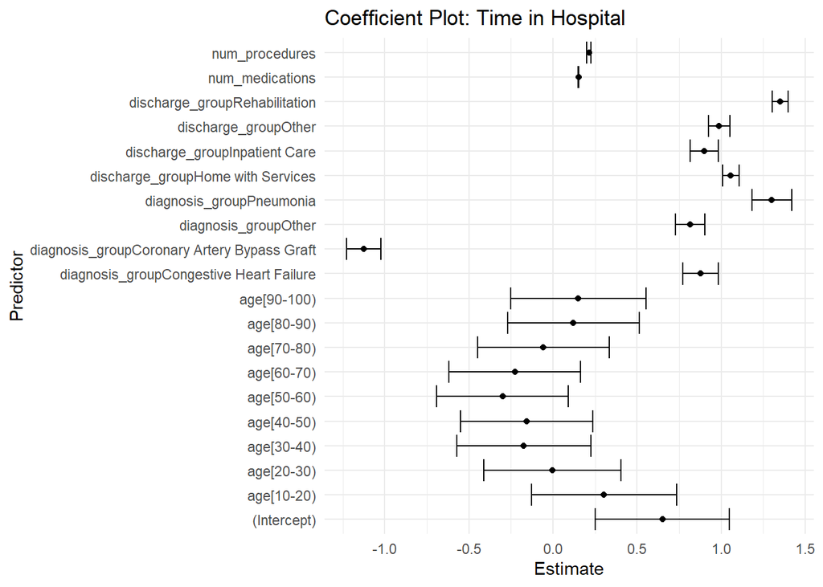

```r
  tidy_lm <- tidy(time_model, conf.int = TRUE)

  # Coefficient plot
  ggplot(tidy_lm, aes(x = estimate, y = term)) +
    geom_point() +
    geom_errorbarh(aes(xmin = conf.low, xmax = conf.high)) +
    labs(title = "Coefficient Plot: Time in Hospital", x = "Estimate", y = "Predictor") +
    theme_minimal()
```

```r
## Predicting readmission

  # Multinomial logistic regression model
  readmission_model <- multinom(readmitted ~ age + discharge_group + num_procedures + num_medications + diagnosis_group,
                                data = cleaned_hospital_data)
  summary(readmission_model)
```

```
## Call:
## multinom(formula = readmitted ~ age + discharge_group + num_procedures +
##     num_medications + diagnosis_group, data = cleaned_hospital_data)
##
## Coefficients:
##     (Intercept) age[10-20) age[20-30) age[30-40) age[40-50) age[50-60)
## >30    2.219840 -0.4312306  -1.333924  -1.043071 -0.8848048 -0.7370727
## NO     4.010076 -1.3719861  -2.315231  -1.998047 -1.9424109 -1.7860281
##     age[60-70) age[70-80) age[80-90) age[90-100)
## >30 -0.8173202 -0.7771187 -0.7272212  -0.8039742
## NO  -1.9170852 -1.9436194 -1.8740685  -1.5831161
##     discharge_groupHome with Services discharge_groupInpatient Care
## >30                        -0.1691191                    -0.7854582
## NO                         -0.3681778                    -0.6655285
##     discharge_groupOther discharge_groupRehabilitation num_procedures
## >30           -0.4554428                    -0.6262807   -0.009130261
## NO             0.3529799                    -0.5967470    0.060169026
##     num_medications diagnosis_groupCongestive Heart Failure
## >30    -0.004719906                             0.009986932
## NO     -0.018506479                            -0.636808794
##     diagnosis_groupCoronary Artery Bypass Graft diagnosis_groupOther
## >30                                  0.10767651          -0.00313206
## NO                                  -0.01943863          -0.13411427
##     diagnosis_groupPneumonia
## >30                0.3318717
## NO                 0.1014458
##
## Std. Errors:
##     (Intercept) age[10-20) age[20-30) age[30-40) age[40-50) age[50-60)
## >30   0.1226559  0.1878047  0.1285377  0.1183946  0.1114553  0.1095778
## NO    0.1249624  0.1861176  0.1296798  0.1213163  0.1154962  0.1138744
##     age[60-70) age[70-80) age[80-90) age[90-100)
## >30  0.1086988  0.1083254  0.1093101   0.1232687
## NO   0.1131041  0.1127924  0.1136746   0.1252365
##     discharge_groupHome with Services discharge_groupInpatient Care
## >30                        0.03276666                    0.05068385
## NO                         0.03210357                    0.04717293
##     discharge_groupOther discharge_groupRehabilitation num_procedures
## >30           0.05201091                    0.03047905    0.007957648
## NO            0.04688209                    0.02914966    0.007568223
##     num_medications diagnosis_groupCongestive Heart Failure
## >30     0.001466395                              0.07337566
## NO      0.001410312                              0.07025507
##     diagnosis_groupCoronary Artery Bypass Graft diagnosis_groupOther
## >30                                  0.07659223           0.06395389
## NO                                   0.07218329           0.05997920
##     diagnosis_groupPneumonia
## >30               0.08665393
## NO                0.08287951
##
## Residual Deviance: 189319.1
## AIC: 189399.1
```

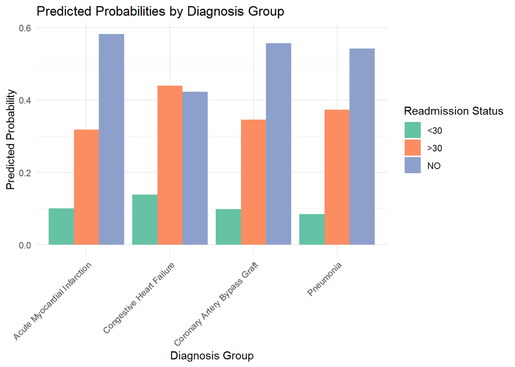

```r
  diagnosis_effect <- effect("diagnosis_group", readmission_model)
  diagnosis_effect_df <- as.data.frame(diagnosis_effect)

  # Melt the data into long format for easier plotting
  melted_diagnosis_effect_df <- melt(diagnosis_effect_df,
                                     id.vars = "diagnosis_group",
                                     measure.vars = c("prob.X.30", "prob.X.30.1", "prob.NO"),
                                     variable.name = "readmission_status",
                                     value.name = "probability")

  # Rename levels of readmission status for clarity
  melted_diagnosis_effect_df$readmission_status <- factor(melted_diagnosis_effect_df$readmission_status,
                                                          levels = c("prob.X.30", "prob.X.30.1", "prob.NO"),
                                                          labels = c("<30", ">30", "NO"))

  # Plot the predicted probabilities
  ggplot(melted_diagnosis_effect_df, aes(x = diagnosis_group, y = probability, fill = readmission_status)) +
    geom_bar(stat = "identity", position = "dodge") +
    scale_x_discrete(limits = c("Acute Myocardial Infarction", "Congestive Heart Failure", "Coronary Artery Bypass Graft", "Pneumonia")) +
    labs(title = "Predicted Probabilities by Diagnosis Group",
         x = "Diagnosis Group",
         y = "Predicted Probability") +
    scale_fill_brewer(palette = "Set2", name = "Readmission Status") +
    theme_minimal() +
    theme(axis.text.x = element_text(angle = 45, hjust = 1))
```

## Part III: Communicating

I was interested in learning what factors contribute to readmission, and especially when the patient’s diagnosis is targeted condition by the Centers for Medicare and Medicaid Services (CMS) and readmission could mean financial penalties for the hospital. I was also interested to learn about what factors increase length of stay, which is another variable that factors heavily into a hospital’s finances.